# **RMS Titanic (Royal Mail Ship Titanic)**

#### Brytyjski transatlantyk typu Olympic w nocy z **14 na 15 kwietnia 1912 roku**, podczas dziewiczego rejsu na trasie Southampton – Cherbourg – Queenstown – Nowy Jork, zderzył się z górą lodową i zatonął. Jego katastrofa spowodowała nowelizację zasad bezpieczeństwa morskiego. Dane o ofiarach są niejednoznaczne. Spośród około **2208** pasażerów i załogi „Titanica” zginęło około **1496 osób**. Przeżyło katastrofę tylko około **712** [(źródło)](https://pl.wikipedia.org/wiki/RMS_Titanic).

### **Poniższa analiza została przeprowadzona na próbie liczącej 1310 pasażerów.**

[figure not shown]

# 1. **Ogólny przegląd danych**

Przykład **5 losowych** wierszy

|  | pclass | survived | name | sex | age | sibsp | parch | ticket | fare | cabin | embarked | boat | body | home.dest |
| --- | --- | --- | --- | --- | --- | --- | --- | --- | --- | --- | --- | --- | --- | --- |
| 1016 | 3.0 | 0.0 | Mernagh, Mr. Robert | male | NaN | 0.0 | 0.0 | 368703 | 7.7500 | NaN | Q | NaN | NaN | NaN |
| 198 | 1.0 | 1.0 | Marvin, Mrs. Daniel Warner (Mary Graham Carmichael Farquarson) | female | 18.0 | 1.0 | 0.0 | 113773 | 53.1000 | D30 | S | 10 | NaN | New York, NY |
| 1151 | 3.0 | 0.0 | Risien, Mrs. Samuel (Emma) | female | NaN | 0.0 | 0.0 | 364498 | 14.5000 | NaN | S | NaN | NaN | NaN |
| 586 | 2.0 | 1.0 | Weisz, Mrs. Leopold (Mathilde Francoise Pede) | female | 29.0 | 1.0 | 0.0 | 228414 | 26.0000 | NaN | S | 10 | NaN | Bromsgrove, England / Montreal, PQ |
| 945 | 3.0 | 1.0 | Lam, Mr. Ali | male | NaN | 0.0 | 0.0 | 1601 | 56.4958 | NaN | S | C | NaN | NaN |

Informacja o **typie danych** dla poszczególnych kolumn oraz **ilości wierszy bez braków**

```
<class 'pandas.core.frame.DataFrame'>
RangeIndex: 1310 entries, 0 to 1309
Data columns (total 14 columns):
 #   Column     Non-Null Count  Dtype
---  ------     --------------  -----
 0   pclass     1309 non-null   float64
 1   survived   1309 non-null   float64
 2   name       1309 non-null   object
 3   sex        1309 non-null   object
 4   age        1046 non-null   float64
 5   sibsp      1309 non-null   float64
 6   parch      1309 non-null   float64
 7   ticket     1309 non-null   object
 8   fare       1308 non-null   float64
 9   cabin      295 non-null    object
 10  embarked   1307 non-null   object
 11  boat       486 non-null    object
 12  body       121 non-null    float64
 13  home.dest  745 non-null    object
dtypes: float64(7), object(7)
memory usage: 143.4+ KB
```

Wartości **unikatowe** w poszczególnych kolumnach

```
pclass          3
survived        2
name         1307
sex             2
age            98
sibsp           7
parch           8
ticket        929
fare          281
cabin         186
embarked        3
boat           27
body          121
home.dest     369
dtype: int64
```

# 2. **Analiza brakujących wartości**

|  | brakujące rzędy | braki wyrażone w procentach |
| --- | --- | --- |
| pclass | 1 | 0.076336 |
| survived | 1 | 0.076336 |
| name | 1 | 0.076336 |
| sex | 1 | 0.076336 |
| age | 264 | 20.152672 |
| sibsp | 1 | 0.076336 |
| parch | 1 | 0.076336 |
| ticket | 1 | 0.076336 |
| fare | 2 | 0.152672 |
| cabin | 1015 | 77.480916 |
| embarked | 3 | 0.229008 |
| boat | 824 | 62.900763 |
| body | 1189 | 90.763359 |
| home.dest | 565 | 43.129771 |

Do analizy przeżycia w katastrofie Titanica, kluczowe są informacje o:

- przeżyciu,

- płci,

- klasie biletu,

- wieku.

Dlatego postanowiono usunąć wszystkie wiersze z brakami w najważniejszych do analizy kolumnach. W wyniku zabiegu otrzymano próbę liczącą **1046 przypadków** .

# 3. **Transformacja danych**

Polegała na:

- utworzeniu nowej kolumny **'płeć'** z wartościami **'kobieta'/'mężczyzna'** na podstawie kolumny **'sex'**;

- utworzeniu kolumny **'przeżycie str'** jako string;

- **zmianie nazw kolumn**;

- **uporządkowaniu kolejności** kolumn;

- sprawdzeniu czy dane zawierają **duplikaty** (nie wykryto).

W wyniku transformacji otrzymano dane gotowe do analizy statystycznej.

| imię i nazwisko | przeżycie str | przeżycie int | płeć | wiek | liczba rodzeńtwa/małżonka | liczba rodziców/dzieci | klasa biletu | cena biletu | nr biletu | nr kabiny | port początkowy | nr łodzi ratunkowej | nr ciała | miejsce docelowe |
| --- | --- | --- | --- | --- | --- | --- | --- | --- | --- | --- | --- | --- | --- | --- |
| Nicola-Yarred, Miss. Jamila | tak | 1 | kobieta | 14 | 1 | 0 | 3 | 11 | 2651 | nan | C | C | nan | nan |
| Maybery, Mr. Frank Hubert | nie | 0 | mężczyzna | 40 | 0 | 0 | 2 | 16 | 239059 | nan | S | nan | nan | Weston-Super-Mare / Moose Jaw, SK |
| Mellinger, Miss. Madeleine Violet | tak | 1 | kobieta | 13 | 0 | 1 | 2 | 20 | 250644 | nan | S | 14 | nan | England / Bennington, VT |
| Aldworth, Mr. Charles Augustus | nie | 0 | mężczyzna | 30 | 0 | 0 | 2 | 13 | 248744 | nan | S | nan | nan | Bryn Mawr, PA, USA |
| Karlsson, Mr. Julius Konrad Eugen | nie | 0 | mężczyzna | 33 | 0 | 0 | 3 | 8 | 347465 | nan | S | nan | nan | nan |

# 4. **Analiza statystyczna**

## 4.1. Ogólne cechy danych liczbowych

|  | przeżycie int | wiek | liczba rodzeńtwa/małżonka | liczba rodziców/dzieci | klasa biletu | cena biletu | nr ciała |
| --- | --- | --- | --- | --- | --- | --- | --- |
| count | 1046.000000 | 1046.000000 | 1046.000000 | 1046.00000 | 1046.000000 | 1045.000000 | 120.00000 |
| mean | 0.408222 | 29.881135 | 0.502868 | 0.42065 | 2.207457 | 36.686080 | 160.87500 |
| std | 0.491740 | 14.413500 | 0.912167 | 0.83975 | 0.841497 | 55.732533 | 98.10392 |
| min | 0.000000 | 0.166700 | 0.000000 | 0.00000 | 1.000000 | 0.000000 | 1.00000 |
| 25% | 0.000000 | 21.000000 | 0.000000 | 0.00000 | 1.000000 | 8.050000 | 71.50000 |
| 50% | 0.000000 | 28.000000 | 0.000000 | 0.00000 | 2.000000 | 15.750000 | 155.50000 |
| 75% | 1.000000 | 39.000000 | 1.000000 | 1.00000 | 3.000000 | 35.500000 | 256.50000 |
| max | 1.000000 | 80.000000 | 8.000000 | 6.00000 | 3.000000 | 512.329200 | 328.00000 |

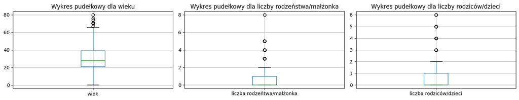

## 4.2. Zależność przeżycia od klasy biletu

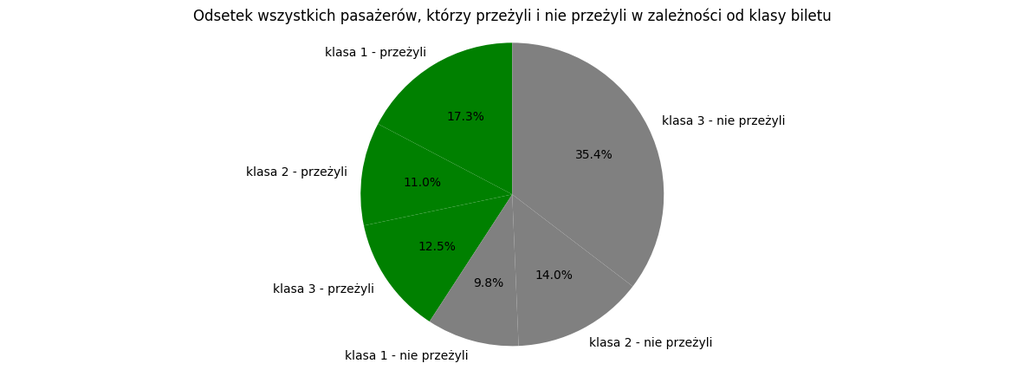

### Odsetek osób z biletem w danej klasie, które przeżyły lub zginęły

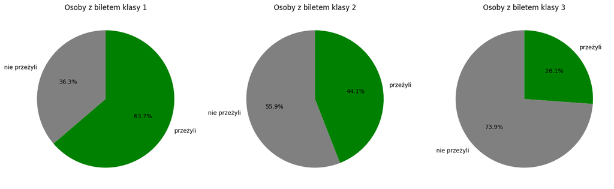

## Wnioski

- W badanej próbie **najwięcej** było **osób** z **biletem klasy 3**.
- **Prawie 60%** wszystkich pasażerów **nie przeżyło**, przy czym zdecydowaną większość (35,4% wszystkich pasażerów) stanowili pasażerowie z biletmi klasy 3.
- **Spośród 40%** pasażerów, którzy **ocaleli**, największy udział miały osoby z **biletem klasy 1**.
- Wykres "Odsetek osób z biletem w danej klasie, które przeżyły lub zginęły" pokazuje, że **największą szansę przeżycia** mieli pasażerowie z **biletami klasy 1** (**63,7%** z tych osób przeżyło), natomiast **najmniejszą szansę przeżycia** miały osoby z **biletami klasy 3** (tylko **26,1%** z nich przeżyło).

## 4.3. Zależność przeżycia od płci

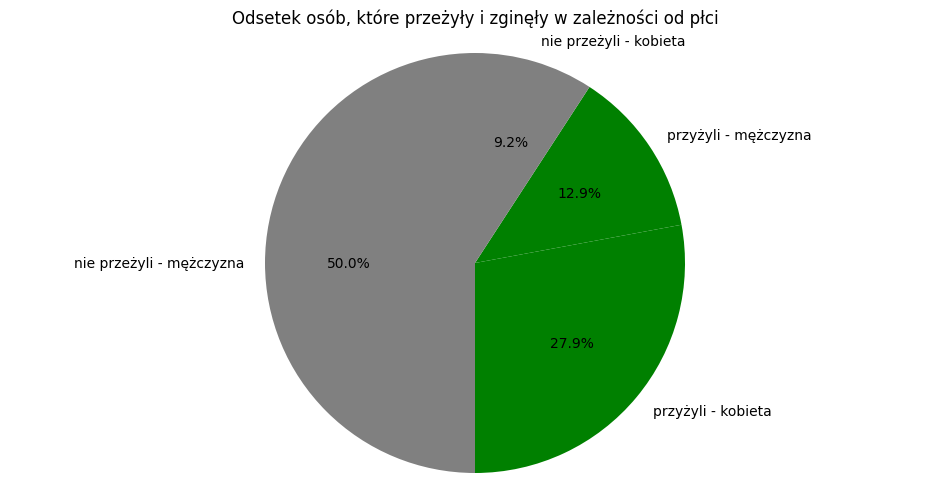

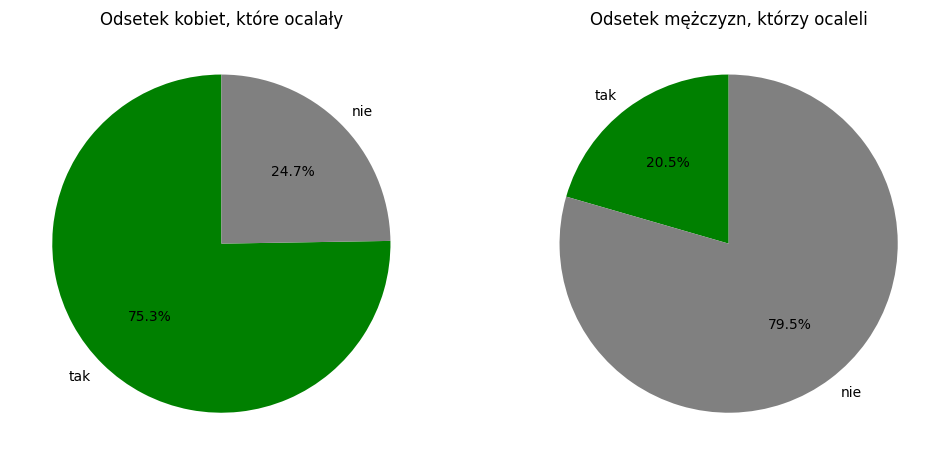

## Wnioski

- W badanej próbie **dominowali liczebnie mężczyźni**, jednak **większość mężczyzn** (79,5%) **nie przeżyła** katostrofy.
- Odmienną zależność można zaobserwować z grupie kobiet, tzn. **większość kobiet przeżyła** (75,3% wszystkich kobiet).
- **Mężczyźni**, którzy **zginęli** stanowią **50,0%** wszystkich pasażerów, natomiast **kobiety**, które **zginęły 9,2%**.
- Spośród uratowanych osób **kobiety** stanowiły około **2/3 wszystkich uratowanych**.

## 4.4. Zależność przeżycia od płci i klasy biletu

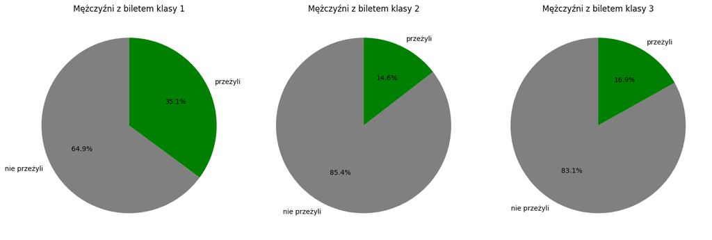

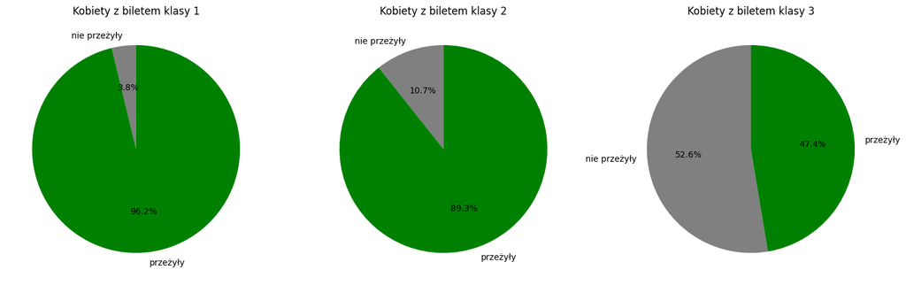

### Odsetek osób z biletem w danej klasie, które przeżyły lub zginęły w zależności od płci

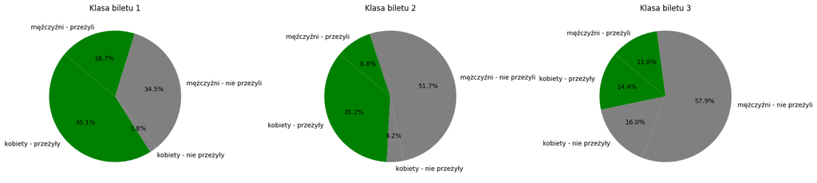

## Wnioski

- Na podstawie powyższej analizy, wynika że **w grupie kobiet** wraz ze **wzrostem klasy biletu** znacząco wzrosła **szansa na przeżycie** (kobiety z biletem w klasie 1 w 96,2% przypadkach przeżyły, w klasie 2 w 89,3%, a w klasie 3 już tylko w 47,4% kobiet przeżyło).
- Także w grupie badanych **mężczyzn**, ci z **biletem w kasie 1** mieli **największą szansę na przeżycie** (35,1% mężczyzn z biletem w klasie 1), natomiast **mężczyźni** z biletami w **klasie 2 i 3** mieli **zbliżone szanse** na przeżycie (przeżyło 14,6% mężczyzn spośród tych z biletem w klasie 2, oraz 16,9% mężczyzn spośród tych z biletem w klasie 3).
- Ostatni wykres pt. "Odsetek osób z biletem w danej klasie, które przeżyły lub zginęły w zależności od płci", ukazuje że **dysproporcja kobiet**, które **przeżyły**, względem **mężczyzn**, którzy **przeżyli**, **zmniejsza się wraz ze spadkiem klasy biletu** (por. klasę biletu 1 z 3).

## 4.5. Rozkład wieku dla mężczyzn i kobiet

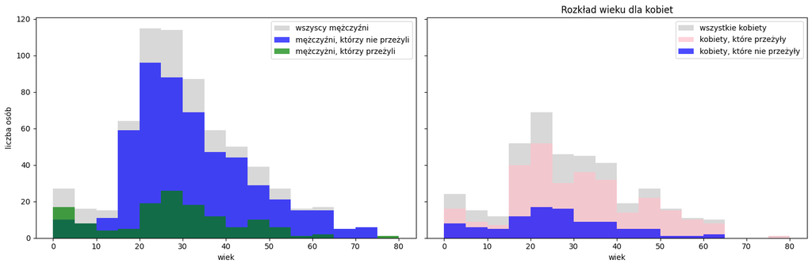

## Wnioski

- **Średni wiek** pasażerów to w przybliżeniu **30 lat**.
- **Najwięcej** podróżujących **mężczyzn** było w wieku **20-35 lat**.
- **Najwięcej** podróżujących **kobiet** było w wieku **15-40 lat**.
- Z rozkładów wieku dla kobiet i mężczyzn wynika, że **grupami uprzywilejowanymi** do uzuskania pomocy były **osoby najstarsze** (75-80 lat) oraz **kobiety w wieku 50-60 lat** - są to grupy wiekowe, które mają najmnieszy odsetek śmiertelności w katastrofie.

# **5. Podsumowanie**

- W analizie przyjęto **ostre kryterium selekcji danych**, tzn. wybrano do analizy tylko te rekordy, które miały pełne dane w kluczowych kolumnach ("przeżycie", "płeć", "wiek"). Ostatecznie statystyki zostały obliczone na podstawie **próby liczącej 1046 przypadków**.
- Uzyskane wyniki pokazały, że **największą szansę na przeżcyie w katastrofie Titanica** miały osoby podróżujące w **1 klasie**.
- W badanej próbie **podróżnymi byli w przeważającej części mężczyźni** (62,9%), lecz zdecydowanie **większe szanse na przeżycie miały kobiety** (spośród uratowanych pasażerów, **kobiety** stanowiły **2/3**).